← simtte · Carlos Serra Traynor

# Simulating from a Cox model

simtte simulates event times from a **hazard**. A Cox model assumes

```
h(t | X) = h0(t) · exp(Xβ)
```

and deliberately leaves the baseline `h0(t)` unspecified. That’s fine for *fitting*, because the partial likelihood never needs `h0`. It isn’t fine for *simulating*, because you can’t draw an event time without a full hazard. So simulating from a Cox model takes three steps:

1. **Choose a baseline `h0(t)`.** Set it yourself (route A) or estimate it from a reference dataset (route B).
2. **Multiply by `exp(Xβ)`.**
3. **Draw event times** from the resulting hazard.

simtte’s M-spline model provides step 1 as a flexible, smooth baseline, and its `covariates` / `beta` arguments provide step 2:

```
sim_tte_ode(model = "mspline")  hazard = exp(mu + lp) · Σ_m coefs[m] · M_m(t)
                                 └── h0(t) = exp(mu) · Σ coefs · M(t)
                                 └── lp = Xβ  (from covariates / beta)
```

Proportional hazards holds by construction, so `coxph()` fitted to the simulated data estimates `β`. That’s the equivalence these scripts check. Note that this isn’t a Cox partial likelihood run backwards: it simulates the **data-generating process** that a Cox model assumes.

## Route A: you set the truth

Three hand-picked baseline shapes (flat, increasing, bathtub), a treatment effect `β = −0.5`, simulate, check that `coxph()` recovers `β` and that the Kaplan–Meier curves match the analytical `S(t | x)`. The full run adds a 200-replicate bias and coverage check.

**Show the script (01_route_a_design.R)**

```
#> Building mspline_ode_k3 ... done.
#> Loading model from cache.
#> Loading model from cache.
#>
#> Route A: beta and baseline-survival recovery
#>       shape    n events beta_true beta_hat     se      z km_gap_control
#>        flat 2000    943      -0.5   -0.520 0.0664 -0.308         0.0201
#>  increasing 2000    885      -0.5   -0.626 0.0692 -1.818         0.0327
#>     bathtub 2000   1000      -0.5   -0.475 0.0641  0.396         0.0207
#>  km_gap_treated dkw_95
#>          0.0164 0.0429
#>          0.0232 0.0429
#>          0.0110 0.0429
#>
#> Figure: figures/route_a_km_vs_truth.png
#>
#> Coverage run: 200 replicates of n = 500 (bathtub baseline) ...
#>   bias 0.0026 (MC SE 0.0091) | empirical SD 0.1282 vs mean model SE 0.1289 | 95% CI coverage 0.940 (MC SE 0.015)
#>
#> Route A: all checks passed.
```

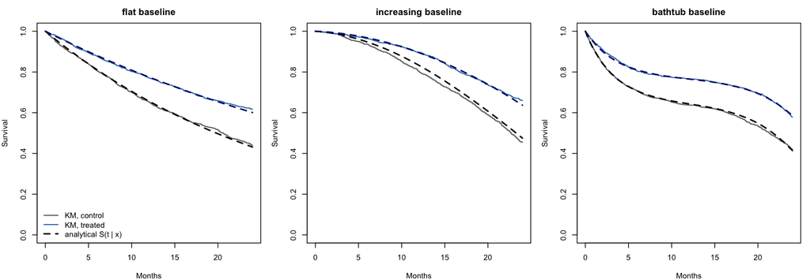

```r
#!/usr/bin/env Rscript
# =============================================================================
# 01_route_a_design.R -- simulate Cox-model data from a baseline YOU choose.
# =============================================================================
# A Cox model says h(t | x) = h0(t) * exp(x * beta) and leaves h0 unspecified.
# To simulate from it you must pick h0; here h0 is simtte's M-spline baseline,
#   h0(t) = exp(mu) * sum_m coefs[m] * M_m(t),
# and the treatment effect enters as exp(trt * beta) through simtte's
# covariates/beta. Proportional hazards therefore holds by construction, so a
# coxph() fit on the simulated data should recover beta, and the Kaplan-Meier
# curves should match the analytical S(t | x) = exp(-H0(t))^exp(x * beta).
#
# Three baseline shapes (flat, increasing, bathtub), one binary covariate.
# This is the design / power-analysis use case: you set the truth.
#
# Usage (from this folder):
#   Rscript 01_route_a_design.R                  # smoke: 1 fit/shape, n = 400
#   COX_SMOKE=false Rscript 01_route_a_design.R  # full: n = 2000 per shape,
#                                                # + 200-replicate coverage run
#
# Output: printed recovery table; figures/route_a_km_vs_truth.png (full mode
#         only -- smoke writes its figure to tempdir()). Stops on a failed
#         check.
# Runtime: smoke ~10 s; full ~1-2 min (mostly the coverage run).
# =============================================================================

suppressPackageStartupMessages({
  library(simtte)
  library(survival)
})

smoke <- !identical(Sys.getenv("COX_SMOKE"), "false")

# ---------------------------------------------------------------------------
# M-spline baseline helpers (the ~10 lines a user needs to evaluate the
# baseline simtte simulates from; simtte does not export these yet).
# ---------------------------------------------------------------------------
# simtte's model = "mspline" uses splines2::mSpline(degree = 2,
# intercept = TRUE). splines2::iSpline() with the same arguments is its exact
# integral (checked to ~1e-8), so the cumulative hazard is closed-form.
ms_hazard <- function(t, knots, coefs, boundary_knots, mu = 0) {
  basis <- splines2::mSpline(t, knots = knots, Boundary.knots = boundary_knots,
    degree = 2, intercept = TRUE)
  exp(mu) * drop(basis %*% coefs)
}
ms_cumhaz <- function(t, knots, coefs, boundary_knots, mu = 0) {
  basis <- splines2::iSpline(t, knots = knots, Boundary.knots = boundary_knots,
    degree = 2, intercept = TRUE)
  exp(mu) * drop(basis %*% coefs)
}
ms_surv <- function(t, knots, coefs, boundary_knots, mu = 0) {
  exp(-ms_cumhaz(t, knots, coefs, boundary_knots, mu))
}
# Coefficients that make sum_m coefs[m] * M_m(t) == 1 everywhere: each
# normalized M-spline integrates to 1, so weighting it by its support width
# divided by its order (3 for degree 2) turns it back into a B-spline, and
# B-splines sum to 1.
ms_flat_coefs <- function(knots, boundary_knots) {
  tk <- c(rep(boundary_knots[1], 3), knots, rep(boundary_knots[2], 3))
  m <- seq_len(length(knots) + 3)
  (tk[m + 3] - tk[m]) / 3
}

# ---------------------------------------------------------------------------
# The truth
# ---------------------------------------------------------------------------
end <- 24                    # months of follow-up (administrative censoring)
knots <- c(6, 12, 18)             # 3 interior knots -> 6 coefficients
boundary_knots <- c(0, end)       # hazard is zero past boundary_knots[2]
beta <- c(trt = -0.5)             # log hazard ratio, treated vs control
flat <- ms_flat_coefs(knots, boundary_knots)

# Shapes are a multiplier on the flat coefficients; mu sets the overall level
# (chosen so roughly half the control arm has an event by month 24).
shapes <- list(
  flat       = list(mu = log(0.035), coefs = flat),
  increasing = list(mu = log(0.03),
                    coefs = flat * c(0.1, 0.3, 0.7, 1.2, 1.8, 2.4)),
  bathtub    = list(mu = log(0.035), coefs = flat * c(3, 1.2, 0.3, 0.3, 1.2, 3))
)

# ---------------------------------------------------------------------------
# Simulate one two-arm cohort and fit coxph()
# ---------------------------------------------------------------------------
simulate_arm_cohort <- function(shape, n, seed) {
  cov <- data.frame(ID = seq_len(n), time = 0, trt = rep(0:1, length.out = n))
  sim <- sim_tte_ode(model = "mspline", knots = knots,
    boundary_knots = boundary_knots, coefs = shape$coefs,
    param = list(mu = shape$mu), n = n, end = end, delta = 1,
    covariates = cov, beta = beta, seed = seed)
  # sim$events carries only ID/sim_time/sim_status: merge the covariate back.
  merge(sim$events, cov[c("ID", "trt")], by = "ID")
}

fit_beta <- function(dat) {
  fit <- coxph(Surv(sim_time, sim_status) ~ trt, data = dat)
  c(estimate = unname(coef(fit)), se = unname(sqrt(vcov(fit))))
}

# Largest vertical gap between an arm's Kaplan-Meier curve and the truth.
# With only administrative censoring, KM is the empirical CDF up to `end`, so
# the Dvoretzky-Kiefer-Wolfowitz bound sqrt(log(2 / 0.05) / (2 n)) is a 95%
# band for that gap -- a principled tolerance rather than a hand-picked one.
km_gap <- function(dat, arm, shape) {
  km <- survfit(Surv(sim_time, sim_status) ~ 1, data = dat[dat$trt == arm, ])
  truth <- ms_surv(km$time, knots, shape$coefs, boundary_knots,
    mu = shape$mu)^exp(beta[["trt"]] * arm)
  max(abs(km$surv - truth))
}

n <- if (smoke) 400 else 2000
cohorts <- Map(simulate_arm_cohort, shapes, n = n, seed = seq_along(shapes))

recovery <- do.call(rbind, Map(function(dat, shape, name) {
  b <- fit_beta(dat)
  data.frame(shape = name, n = n, events = sum(dat$sim_status),
    beta_true = beta[["trt"]], beta_hat = b[["estimate"]], se = b[["se"]],
    z = (b[["estimate"]] - beta[["trt"]]) / b[["se"]],
    km_gap_control = km_gap(dat, 0, shape),
    km_gap_treated = km_gap(dat, 1, shape),
    dkw_95 = sqrt(log(2 / 0.05) / n))   # DKW with n / 2 per arm
}, cohorts, shapes, names(shapes)))

cat("\nRoute A: beta and baseline-survival recovery\n")
print(format(recovery, digits = 3), row.names = FALSE)

stopifnot(
  "beta_hat more than 3 SE from the truth" = all(abs(recovery$z) < 3),
  "KM strays outside the 95% DKW band" =
    all(pmax(recovery$km_gap_control, recovery$km_gap_treated) <
      recovery$dkw_95)
)

# ---------------------------------------------------------------------------
# Figure: KM by arm vs the analytical survival, one panel per shape
# ---------------------------------------------------------------------------
fig_dir <- if (smoke) tempdir() else "figures"
dir.create(fig_dir, showWarnings = FALSE)
png(file.path(fig_dir, "route_a_km_vs_truth.png"), width = 1500, height = 520,
  res = 130)
par(mfrow = c(1, 3), mar = c(4, 4, 2.5, 1))
grid_t <- seq(0, end, length.out = 200)
for (name in names(shapes)) {
  shape <- shapes[[name]]
  plot(survfit(Surv(sim_time, sim_status) ~ trt, data = cohorts[[name]]),
    col = c("grey45", "steelblue"), lwd = 1.5, ylim = c(0, 1),
    xlab = "Months", ylab = "Survival", main = paste0(name, " baseline"))
  for (arm in 0:1) {
    lines(grid_t, ms_surv(grid_t, knots, shape$coefs, boundary_knots,
      mu = shape$mu)^exp(beta[["trt"]] * arm),
      col = c("black", "navy")[arm + 1], lty = 2, lwd = 2)
  }
  if (name == "flat") {
    legend("bottomleft", bty = "n", lty = c(1, 1, 2), lwd = c(1.5, 1.5, 2),
      col = c("grey45", "steelblue", "black"),
      legend = c("KM, control", "KM, treated", "analytical S(t | x)"))
  }
}
invisible(dev.off())
cat("\nFigure:", file.path(fig_dir, "route_a_km_vs_truth.png"), "\n")

# ---------------------------------------------------------------------------
# Full mode only: bias and 95% CI coverage over 200 replicates
# ---------------------------------------------------------------------------
# A single fit shows point recovery; coverage is what shows the simulator is
# right (a subtly biased simulator can pass one fit by luck). Many moderate
# calls rather than one huge one: sim_tte_ode()'s per-subject event
# resolution currently scales worse than linearly in n (see the report).
if (!smoke) {
  n_rep <- 200
  n_per_rep <- 500
  cat("\nCoverage run:", n_rep, "replicates of n =", n_per_rep,
    "(bathtub baseline) ...\n")
  # suppressMessages(): in ~1 replicate in 10, one or two subjects near the
  # bathtub's steep early hazard take simtte's documented reported-grid
  # refinement fallback, and simtte says so each time. That is informational
  # (see ?sim_tte_ode "Event-time refinement"), and the coverage result below
  # already includes those subjects -- silenced only so the log stays readable.
  reps <- t(vapply(seq_len(n_rep), function(r) {
    suppressMessages(fit_beta(
      simulate_arm_cohort(shapes$bathtub, n_per_rep, seed = 1000 + r)))
  }, numeric(2)))
  coverage <- mean(abs(reps[, "estimate"] - beta[["trt"]]) <
    qnorm(0.975) * reps[, "se"])
  mc_se <- sqrt(0.95 * 0.05 / n_rep)
  cat(sprintf(paste0("  bias %.4f (MC SE %.4f) | empirical SD %.4f vs ",
    "mean model SE %.4f | 95%% CI coverage %.3f (MC SE %.3f)\n"),
    mean(reps[, "estimate"]) - beta[["trt"]],
    sd(reps[, "estimate"]) / sqrt(n_rep), sd(reps[, "estimate"]),
    mean(reps[, "se"]), coverage, mc_se))
  stopifnot(
    "bias is more than 3 Monte Carlo SE from zero" =
      abs(mean(reps[, "estimate"]) - beta[["trt"]]) <
        3 * sd(reps[, "estimate"]) / sqrt(n_rep),
    "coverage is more than 3 Monte Carlo SE from 0.95" =
      abs(coverage - 0.95) < 3 * mc_se
  )
}

cat("\nRoute A: all checks passed.\n")
```

## Route B: estimate from `survival::lung`, then simulate

Fit an M-spline proportional-hazards model to `survival::lung` (sex effect) by maximum likelihood **on simtte’s own basis**, check it against `coxph()`, then simulate a new cohort from the fit and check the round trip.

**Show the script (02_route_b_lung.R)**

```
#>
#> Route B, step 1-2: M-spline PH fit on survival::lung vs coxph()
#>                         fit beta_female    se
#>            M-spline PH (ML)      -0.536 0.167
#>  coxph (partial likelihood)      -0.531 0.167
#>   max |Breslow S0(t) - M-spline S0(t)| (male baseline): 0.033
#>   fitted knots (months):  3.03  5.48  7.43 11.10 15.63
#>   fitted coefs:          0.0489 0.0820 0.1708 0.3182 0.3405 0.9033 1.6797 0.0162
#> Building mspline_ode_k5 ... done.
#>
#> Route B, step 3: simulated cohort (n = 2000 ) recovers the fit
#>  truth_beta coxph_beta     se      z km_gap_male km_gap_female dkw_95_male
#>      -0.536     -0.576 0.0492 -0.808      0.0284        0.0308       0.039
#>  dkw_95_female
#>         0.0484
#>
#> Figure: figures/route_b_lung_fit.png
#>
#> Route B: all checks passed.
```

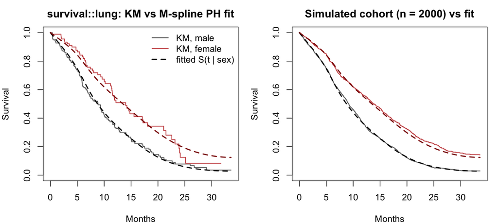

```r
#!/usr/bin/env Rscript
# =============================================================================
# 02_route_b_lung.R -- estimate a baseline from reference data, then simulate.
# =============================================================================
# Route A chose h0(t) by hand. Here h0(t) is ESTIMATED from a real dataset
# (survival::lung, NCCTG advanced lung cancer, 228 patients, 165 deaths) and
# new cohorts are simulated from the fit:
#
#   1. Fit a proportional-hazards model whose baseline is simtte's own M-spline
#      basis, h(t | x) = sum_m coefs[m] * M_m(t) * exp(female * beta), by
#      maximum likelihood. Fitting on the SAME basis simtte simulates from
#      means the fitted coefs go straight into sim_tte_ode() -- no conversion.
#   2. Sanity-check the fit against survival::coxph() on lung: beta should be
#      close to the Cox estimate, the baseline close to the Breslow estimate.
#   3. Simulate a new cohort from the fit (same sex mix) and check that coxph()
#      recovers the fitted beta and KM tracks the fitted survival curves.
#
# Usage (from this folder):
#   Rscript 02_route_b_lung.R                  # smoke: simulated cohort n = 400
#   COX_SMOKE=false Rscript 02_route_b_lung.R  # full: simulated cohort n = 2000
#
# Output: printed fit/recovery tables; figures/route_b_lung_fit.png (full mode
#         only -- smoke writes its figure to tempdir()). Stops on a failed
#         check.
# Runtime: seconds, either mode.
# =============================================================================

suppressPackageStartupMessages({
  library(simtte)
  library(survival)
})

smoke <- !identical(Sys.getenv("COX_SMOKE"), "false")
set.seed(20260929)

# ---------------------------------------------------------------------------
# M-spline baseline helpers (identical to 01_route_a_design.R; repeated so
# each script stands alone).
# ---------------------------------------------------------------------------
# simtte's model = "mspline" uses splines2::mSpline(degree = 2,
# intercept = TRUE). splines2::iSpline() with the same arguments is its exact
# integral (checked to ~1e-8), so the cumulative hazard is closed-form.
ms_hazard <- function(t, knots, coefs, boundary_knots, mu = 0) {
  basis <- splines2::mSpline(t, knots = knots, Boundary.knots = boundary_knots,
    degree = 2, intercept = TRUE)
  exp(mu) * drop(basis %*% coefs)
}
ms_cumhaz <- function(t, knots, coefs, boundary_knots, mu = 0) {
  basis <- splines2::iSpline(t, knots = knots, Boundary.knots = boundary_knots,
    degree = 2, intercept = TRUE)
  exp(mu) * drop(basis %*% coefs)
}
ms_surv <- function(t, knots, coefs, boundary_knots, mu = 0) {
  exp(-ms_cumhaz(t, knots, coefs, boundary_knots, mu))
}
# Coefficients that make sum_m coefs[m] * M_m(t) == 1 everywhere (see
# 01_route_a_design.R); used here only as the fit's starting shape.
ms_flat_coefs <- function(knots, boundary_knots) {
  tk <- c(rep(boundary_knots[1], 3), knots, rep(boundary_knots[2], 3))
  m <- seq_len(length(knots) + 3)
  (tk[m + 3] - tk[m]) / 3
}

# ---------------------------------------------------------------------------
# Reference data
# ---------------------------------------------------------------------------
ref <- data.frame(
  time   = lung$time / 30.4375,       # days -> months
  status = as.integer(lung$status == 2),  # lung codes death as 2
  female = as.integer(lung$sex == 2)
)
boundary_knots <- c(0, max(ref$time))
# 5 interior knots at event-time quantiles (the usual flexible-parametric
# placement); simtte ships 3, 5 or 7 interior knots for model = "mspline".
knots <- unname(quantile(ref$time[ref$status == 1], probs = (1:5) / 6))

# ---------------------------------------------------------------------------
# 1. Maximum-likelihood fit on simtte's basis
# ---------------------------------------------------------------------------
# Log-likelihood for right-censored data under h(t | x) = h0(t) exp(x beta):
#   sum_i [ d_i * (log h0(t_i) + x_i beta) - exp(x_i beta) * H0(t_i) ]
# coefs are fitted on the log scale (keeps them non-negative, unconstrained
# optimisation); simtte's mu is fixed at 0 because it only rescales coefs.
n_coef <- length(knots) + 3
neg_loglik <- function(par) {
  coefs <- exp(par[seq_len(n_coef)])
  beta <- par[[n_coef + 1]]
  lp <- ref$female * beta
  h0 <- ms_hazard(ref$time[ref$status == 1], knots, coefs, boundary_knots)
  H0 <- ms_cumhaz(ref$time, knots, coefs, boundary_knots)
  -(sum(log(h0) + lp[ref$status == 1]) - sum(exp(lp) * H0))
}
# Start from a flat hazard at the crude event rate, beta = 0.
crude_rate <- sum(ref$status) / sum(ref$time)
start <- c(log(crude_rate * ms_flat_coefs(knots, boundary_knots)), 0)
opt <- optim(start, neg_loglik, method = "BFGS", hessian = TRUE,
  control = list(maxit = 1000))
stopifnot("optim() did not converge" = opt$convergence == 0)

coefs_hat <- exp(opt$par[seq_len(n_coef)])
beta_hat <- opt$par[[n_coef + 1]]
beta_hat_se <- sqrt(diag(solve(opt$hessian)))[[n_coef + 1]]

# ---------------------------------------------------------------------------
# 2. Sanity check against coxph() on the reference data
# ---------------------------------------------------------------------------
cox_ref <- coxph(Surv(time, status) ~ female, data = ref)
# Breslow baseline survival for a male (female = 0) patient, at event times.
breslow <- survfit(cox_ref, newdata = data.frame(female = 0))
baseline_gap <- max(abs(breslow$surv -
  ms_surv(breslow$time, knots, coefs_hat, boundary_knots)))

cat("\nRoute B, step 1-2: M-spline PH fit on survival::lung vs coxph()\n")
print(format(data.frame(
  fit = c("M-spline PH (ML)", "coxph (partial likelihood)"),
  beta_female = c(beta_hat, unname(coef(cox_ref))),
  se = c(beta_hat_se, unname(sqrt(vcov(cox_ref))))
), digits = 3), row.names = FALSE)
cat(sprintf("  max |Breslow S0(t) - M-spline S0(t)| (male baseline): %.3f\n",
  baseline_gap))
cat("  fitted knots (months):", format(knots, digits = 3), "\n")
cat("  fitted coefs:         ", format(coefs_hat, digits = 3), "\n")

stopifnot(
  "M-spline beta differs from coxph's by more than half an SE" =
    abs(beta_hat - coef(cox_ref)[[1]]) < 0.5 * sqrt(vcov(cox_ref))[1, 1],
  "M-spline baseline strays more than 0.05 from Breslow" = baseline_gap < 0.05
)

# ---------------------------------------------------------------------------
# 3. Simulate a new cohort from the fit
# ---------------------------------------------------------------------------
# Same sex mix as lung; fitted coefs and beta are now the truth. Only
# administrative censoring at the end of lung's follow-up -- add
# simtte::add_censoring() on top if you also want random dropout.
n <- if (smoke) 400 else 2000
cov <- data.frame(ID = seq_len(n), time = 0,
  female = rbinom(n, 1, mean(ref$female)))
sim <- sim_tte_ode(model = "mspline", knots = knots,
  boundary_knots = boundary_knots, coefs = coefs_hat, param = list(mu = 0),
  n = n, end = boundary_knots[2], delta = 1,
  # Use a seed DIFFERENT from the set.seed() that drew `female` above:
  # sim_tte_ode(seed = ) restarts the RNG, so reusing that value would make
  # each subject's event-time uniform U equal to the draw that set their sex
  # -- tying event time to sex and wrecking the simulated effect.
  covariates = cov, beta = c(female = beta_hat), seed = 1)
# sim$events carries only ID/sim_time/sim_status: merge the covariate back.
sim_dat <- merge(sim$events, cov[c("ID", "female")], by = "ID")

cox_sim <- coxph(Surv(sim_time, sim_status) ~ female, data = sim_dat)
z <- (coef(cox_sim)[[1]] - beta_hat) / sqrt(vcov(cox_sim))[1, 1]

# KM vs fitted survival per sex, with the same 95% DKW tolerance as route A
# (valid here because the simulated data have only administrative censoring).
km_gap <- vapply(0:1, function(f) {
  km <- survfit(Surv(sim_time, sim_status) ~ 1,
    data = sim_dat[sim_dat$female == f, ])
  truth <- ms_surv(km$time, knots, coefs_hat, boundary_knots)^exp(beta_hat * f)
  max(abs(km$surv - truth))
}, numeric(1))
dkw_95 <- sqrt(log(2 / 0.05) / (2 * table(factor(cov$female, 0:1))))

cat("\nRoute B, step 3: simulated cohort (n =", n, ") recovers the fit\n")
print(format(data.frame(
  truth_beta = beta_hat, coxph_beta = coef(cox_sim)[[1]],
  se = sqrt(vcov(cox_sim))[1, 1], z = z,
  km_gap_male = km_gap[1], km_gap_female = km_gap[2],
  dkw_95_male = dkw_95[[1]], dkw_95_female = dkw_95[[2]]
), digits = 3), row.names = FALSE)

stopifnot(
  "simulated coxph beta more than 3 SE from the fitted beta" = abs(z) < 3,
  "simulated KM strays outside the 95% DKW band" = all(km_gap < dkw_95)
)

# ---------------------------------------------------------------------------
# Figure: (left) the fit on lung; (right) the simulated cohort vs the fit
# ---------------------------------------------------------------------------
fig_dir <- if (smoke) tempdir() else "figures"
dir.create(fig_dir, showWarnings = FALSE)
png(file.path(fig_dir, "route_b_lung_fit.png"), width = 1200, height = 540,
  res = 130)
par(mfrow = c(1, 2), mar = c(4, 4, 2.5, 1))
grid_t <- seq(0, boundary_knots[2], length.out = 200)
fitted_curves <- function() {
  for (f in 0:1) {
    lines(grid_t, ms_surv(grid_t, knots, coefs_hat, boundary_knots)^
      exp(beta_hat * f), col = c("black", "darkred")[f + 1], lty = 2, lwd = 2)
  }
}
plot(survfit(Surv(time, status) ~ female, data = ref), col = c("grey45",
  "indianred"), lwd = 1.5, xlab = "Months", ylab = "Survival",
  main = "survival::lung: KM vs M-spline PH fit")
fitted_curves()
legend("topright", bty = "n", lty = c(1, 1, 2), lwd = c(1.5, 1.5, 2),
  col = c("grey45", "indianred", "black"),
  legend = c("KM, male", "KM, female", "fitted S(t | sex)"))
plot(survfit(Surv(sim_time, sim_status) ~ female, data = sim_dat),
  col = c("grey45", "indianred"), lwd = 1.5, xlab = "Months",
  ylab = "Survival", main = paste0("Simulated cohort (n = ", n, ") vs fit"))
fitted_curves()
invisible(dev.off())
cat("\nFigure:", file.path(fig_dir, "route_b_lung_fit.png"), "\n")

cat("\nRoute B: all checks passed.\n")
```

## Which route when

- **Route A: design and power.** You decide the truth (baseline shape and effect size) and ask what a trial would see.
- **Route B: mimic a real dataset.** You want new cohorts that look like an observed one, for example to try a different effect size, sample size or covariate mix against a realistic baseline.

Rendered with simtte 1.1.0 (development version, GitHub f601af8) on 18 October 2026.